# **RNN-BASED TRAFFIC FORECASTING PIPELINE**

**SUBJECT- M507C METHODS OF PREDICTION**

**STUDENT NAME- ASHISH TIWARI**

**GH NUMBER- 1045433**

**INTRODUCTION**

The goal of this project is to employ Recurrent Neural Network(RNN) models to document a neural network based forecasting system . The goal is to use deep learning techniques to support datadriven decisionnmaking by utilizing temporal patterrn in sequntial data to produce precise future predictions.

**BUSINESS PROBLEMS**

- Using time-series data to predict future trends accurately is a challenging for business.
- Complex temporal links are bound with the comprehension of traditional forecasting methods
- Inaccurate forecasts lead to poor prepration, higher costs, and missed opportunities

**SUMMARY OF THE BUSINESS ISSUE**

- To learn sequential paterns, create a fore casting model based on RNNs
- Boost prediction accuracy in comparison to traditional statistical methods.
- Use time-series data from the past to verify the MOdel's functionality

**DATASET LINK -**

https://www.kaggle.com/datasets/pooriamst/metro-interstate-traffic-volume

**1- INITIALIZATION AND DATA LOADING**

**1.1 IMPORTING LIBRARIES**

This section shows all imports necessary libraries for data preprocessing, visualization, handing holidays and creating LSTM-based neural network models using TensorFlow

```python
import io
import warnings
warnings.filterwarnings('ignore')

import numpy as np
import pandas as pd

import holidays
import matplotlib.pyplot as plt
import seaborn as sns

import tensorflow as tf
from tensorflow.keras.models import Sequential
from tensorflow.keras.layers import LSTM, Dense, Dropout, BatchNormalization
from tensorflow.keras.callbacks import EarlyStopping, ReduceLROnPlateau
```

**1.2 LOADING THE DATASET**

```python
df_path = pd.read_csv("/content/Metro_Interstate_Traffic_Volume.csv")
```

**1.3 VIEWING DATA HEADS**

```python
print(df_path.head())
```

```
  holiday    temp  rain_1h  snow_1h  clouds_all weather_main  \
0     NaN  288.28      0.0      0.0          40       Clouds
1     NaN  289.36      0.0      0.0          75       Clouds
2     NaN  289.58      0.0      0.0          90       Clouds
3     NaN  290.13      0.0      0.0          90       Clouds
4     NaN  291.14      0.0      0.0          75       Clouds

  weather_description            date_time  traffic_volume
0    scattered clouds  2012-10-02 09:00:00            5545
1       broken clouds  2012-10-02 10:00:00            4516
2     overcast clouds  2012-10-02 11:00:00            4767
3     overcast clouds  2012-10-02 12:00:00            5026
4       broken clouds  2012-10-02 13:00:00            4918
```

**2- EXPLORATORY DATA ANALYSIS(EDA)**

**2.1 INITIAL GAP ANALYSIS AND MISSING TIME STAMPS**

This code resamples the dataset to hourly frequency, sets and sorts the datetime index, eliminates duplicate timestamps,and changes the date coloumn to date time format. Adter that it does exploratory data analysis(EDA) by finding missing values, which makes it possiblento find temporal gaps and problems with the quality of data in time series dataset.

```python
df_path['date_time'] = pd.to_datetime(df_path['date_time'])

df_path = df_path.drop_duplicates(subset=['date_time'], keep='last')
df_path = df_path.set_index('date_time')
df_path.sort_index(inplace=True)

df_hourly_check = df_path.asfreq('h')

print("EDA: Initial Gap Analysis (Count of NaNs per column):")
print(df_hourly_check.isnull().sum())
```

```
EDA: Initial Gap Analysis (Count of NaNs per column):
holiday                52498
temp                   11976
rain_1h                11976
snow_1h                11976
clouds_all             11976
weather_main           11976
weather_description    11976
traffic_volume         11976
dtype: int64
```

**2.2 HANDLING MISSING VALUES (EDA CHECK)**

This function examines the size of the dataset before and after cleaning, elimiates superfluous coloumns, eliminates rows with missing traffic volume values, and verifiesthe remaining missing values in important weather and traffic related aspects

```python
df_path = df_path.drop(columns=['holiday'], errors='ignore')

df_path_cleaned = df_path.dropna(subset=['traffic_volume'])

print(f"Original number of rows: {len(df_path)}")
print(f"Number of rows after dropping missing traffic volume: {len(df_path_cleaned)}")

print("\nRemaining NaNs in weather columns:")
print(df_path_cleaned[['temp', 'rain_1h', 'snow_1h', 'clouds_all', "traffic_volume"]].isnull().sum())
```

```
Original number of rows: 40575
Number of rows after dropping missing traffic volume: 40575

Remaining NaNs in weather columns:
temp              0
rain_1h           0
snow_1h           0
clouds_all        0
traffic_volume    0
dtype: int64
```

**2.3 VISUALIZING HOURLY AND DAILY SEASONALITY THROUGH HEATMAP**

[figure not shown]

```python
pivot_table = df_path_cleaned.pivot_table(values='traffic_volume',
                             index='date_time',
                             columns='weather_main',
                             aggfunc='mean')

plt.figure(figsize=(10, 8))
sns.heatmap(pivot_table, cmap='magma_r', annot=True, fmt=".1f")
plt.title('Hourly and Daily Seasonality Heatmap')
plt.xlabel('Weather Main')
plt.ylabel('Date Time')
plt.show()
```

**2.4 CHECKING SKEWNESS OF TRAFFIC VOLUME**

In order to evaluate the asymetry or variance of the traffic volume distribution, this function computes its skewness. It helps indentify whether datadjustments would be necessary prior to modeling to enhance learning stability and prediction accuracy by classfying the data to modeling to enhance learning stability and prediction accuracy by classyfying the data as extremely skewed, moderately skewed, or roughly symmetric based on the skewness level

```python
skewness_value = df_path_cleaned['traffic_volume'].skew()

print(f"The skewness of the traffic volume is: {skewness_value:.2f}")

 "Interpretation guide:"
if skewness_value > 1 or skewness_value < -1:
    print("Interpretation: Highly skewed.")
elif (skewness_value > 0.5 and skewness_value < 1) or (skewness_value < -0.5 and skewness_value > -1):
    print("Interpretation: Moderately skewed.")
else:
    print("Interpretation: Approximately symmetric.")
```

```
The skewness of the traffic volume is: -0.11
Interpretation: Approximately symmetric.
```

**2.5 VISUALIZING THE SKEWNESS**

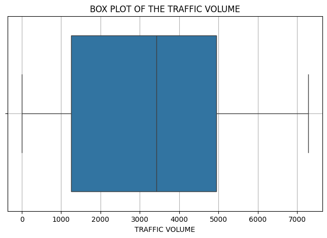

```python
plt.figure(figsize=(8, 5))
sns.boxplot(x=df_path['traffic_volume'])
plt.title('BOX PLOT OF THE TRAFFIC VOLUME')
plt.xlabel('TRAFFIC VOLUME')
plt.grid(True)
plt.show()
```

**2.6 VISUALIZING RELATONSHIP WITH WEATHER VARIABLES**

By displaying the link between temperature and traffic voume, this scatter plot makes it easier to spot trends, correlations, and patterns of fluctuation in the data

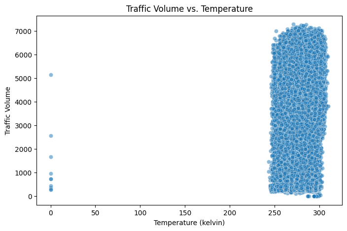

```python
plt.figure(figsize=(8, 5))
sns.scatterplot(data=df_path, x='temp', y='traffic_volume', alpha=0.5)
plt.title('Traffic Volume vs. Temperature')
plt.xlabel('Temperature (kelvin)')
plt.ylabel('Traffic Volume')
plt.show()
```

**3 - DATA CLEANING AND PREPROCESSING**

**3.1 ENSURING UNIFORM HOURLY FREQUENCY**

This code aggregates numerical features by their mean values inside each hour after resampling the time-series dataset to an hourly frequency. For dependable time series analysis and training RNN/LSTM models hat rely on evenly spaced sequntial data, it standardizes temporal granualarity, manages erratc time stamps, and guarantees consistent, time intervals.

```python
df_path = df_path.resample('h').mean(numeric_only=True)
print("DataFrame after resampling to hourly frequency:")
print(df_path.head())
```

[output not shown]

**3.2 PERFORMING CATEGORICAL TO NUMERICAL CONVERSION**

```python
df_base = df_path_cleaned.copy()
df_base['temp_celsius'] = df_base['temp'] - 273.15


numeric_cols = df_base.select_dtypes(include=np.number).columns.tolist()
categorical_cols = [col for col in ['weather_main', 'weather_description'] if col in df_base.columns]

df_numeric_resampled = df_base[numeric_cols].resample('h').mean()

df_categorical_resampled = df_base[categorical_cols].resample('h').agg(lambda x: x.mode()[0] if not x.mode().empty else np.nan)

df_processing = pd.merge(df_numeric_resampled, df_categorical_resampled,
                         left_index=True, right_index=True, how='left')

df_processing.dropna(subset=['traffic_volume'], inplace=True)

df_path_final_cleaned = df_processing.drop(columns=['weather_description'], errors='ignore')

df_encoded = pd.get_dummies(df_path_final_cleaned, columns=['weather_main'], prefix='weather', dtype=int)

print("Columns in the new encoded DataFrame:")
print(df_encoded.columns)
print("\nHead of the new weather indicator columns:")
print(df_encoded.filter(regex='^weather_').head())
```

```
Columns in the new encoded DataFrame:
Index(['temp', 'rain_1h', 'snow_1h', 'clouds_all', 'traffic_volume',
       'temp_celsius', 'weather_Clear', 'weather_Clouds', 'weather_Drizzle',
       'weather_Fog', 'weather_Haze', 'weather_Mist', 'weather_Rain',
       'weather_Smoke', 'weather_Snow', 'weather_Squall',
       'weather_Thunderstorm'],
      dtype='object')

Head of the new weather indicator columns:
                     weather_Clear  weather_Clouds  weather_Drizzle  \
date_time
2012-10-02 09:00:00              0               1                0
2012-10-02 10:00:00              0               1                0
2012-10-02 11:00:00              0               1                0
2012-10-02 12:00:00              0               1                0
2012-10-02 13:00:00              0               1                0

                     weather_Fog  weather_Haze  weather_Mist  weather_Rain  \
date_time
2012-10-02 09:00:00            0             0             0             0
2012-10-02 10:00:00            0             0             0             0
2012-10-02 11:00:00            0             0             0             0
2012-10-02 12:00:00            0             0             0             0
2012-10-02 13:00:00            0             0             0             0

                     weather_Smoke  weather_Snow  weather_Squall  \
date_time
2012-10-02 09:00:00              0             0               0
2012-10-02 10:00:00              0             0               0
2012-10-02 11:00:00              0             0               0
2012-10-02 12:00:00              0             0               0
2012-10-02 13:00:00              0             0               0

                     weather_Thunderstorm
date_time
2012-10-02 09:00:00                     0
2012-10-02 10:00:00                     0
2012-10-02 11:00:00                     0
2012-10-02 12:00:00                     0
2012-10-02 13:00:00                     0
```

**3.3 APPLYING LOG TRANSFORMATION ON TARGET VARIABLE**

To reduce/lessen skewness and stablize variane, this code transforsthe traffic volume features using the log-plus one method. Neural networks may learn patterns more easily because to the transformation, which helps compress extreme values while maintaining relative difference. Printing the original and transformed values enable direct comparison, maintaining numerical stability during model training and forecasting, and confirming the effect of normalization

```python
df_encoded.loc[:, 'traffic_volume_log'] = np.log1p(df_encoded['traffic_volume'])

print("Original Volume (Head):")
print(df_encoded['traffic_volume'].head())
print("\nLog-Transformed Volume (Head):")
print(df_encoded['traffic_volume_log'].head())
```

```
Original Volume (Head):
date_time
2012-10-02 09:00:00    5545.0
2012-10-02 10:00:00    4516.0
2012-10-02 11:00:00    4767.0
2012-10-02 12:00:00    5026.0
2012-10-02 13:00:00    4918.0
Name: traffic_volume, dtype: float64

Log-Transformed Volume (Head):
date_time
2012-10-02 09:00:00    8.620832
2012-10-02 10:00:00    8.415603
2012-10-02 11:00:00    8.469682
2012-10-02 12:00:00    8.522579
2012-10-02 13:00:00    8.500861
Name: traffic_volume_log, dtype: float64
```

**3.4 FIXING EXOGENOUS FACTOR (here HOIDAYS)**

A binary features that indicates if each timestamp falls o US public holidays are added by this code. "As the dataset is from the US highway". Holidays are marked as 1 and non holidays as 0 by mapping the datetime index to the nation's holiday calendar. This helps the model indentify possible differnces in traffic volume brought on by holiday effects.

```python
country_holidays = holidays.country_holidays('US')

df_encoded.loc[:, 'is_holiday'] = df_encoded.index.map(lambda x: x in country_holidays).astype(int)

print("\n'is_holiday' column created:")

print("\n'is_holiday' column created:")
print(df_encoded[['is_holiday']].head(50))
print(f"Total holidays identified: {df_encoded['is_holiday'].sum()}")
```

```
'is_holiday' column created:

'is_holiday' column created:
                     is_holiday
date_time
2012-10-02 09:00:00           0
2012-10-02 10:00:00           0
2012-10-02 11:00:00           0
2012-10-02 12:00:00           0
2012-10-02 13:00:00           0
2012-10-02 14:00:00           0
2012-10-02 15:00:00           0
2012-10-02 16:00:00           0
2012-10-02 17:00:00           0
2012-10-02 18:00:00           0
2012-10-02 19:00:00           0
2012-10-02 20:00:00           0
2012-10-02 21:00:00           0
2012-10-02 22:00:00           0
2012-10-02 23:00:00           0
2012-10-03 00:00:00           0
2012-10-03 01:00:00           0
2012-10-03 02:00:00           0
2012-10-03 03:00:00           0
2012-10-03 04:00:00           0
2012-10-03 05:00:00           0
2012-10-03 06:00:00           0
2012-10-03 08:00:00           0
2012-10-03 09:00:00           0
2012-10-03 12:00:00           0
2012-10-03 13:00:00           0
2012-10-03 14:00:00           0
2012-10-03 15:00:00           0
2012-10-03 16:00:00           0
2012-10-03 18:00:00           0
2012-10-03 19:00:00           0
2012-10-03 20:00:00           0
2012-10-03 21:00:00           0
2012-10-03 22:00:00           0
2012-10-03 23:00:00           0
2012-10-04 00:00:00           0
2012-10-04 01:00:00           0
2012-10-04 02:00:00           0
2012-10-04 03:00:00           0
2012-10-04 04:00:00           0
2012-10-04 05:00:00           0
2012-10-04 06:00:00           0
2012-10-04 07:00:00           0
2012-10-04 08:00:00           0
2012-10-04 09:00:00           0
2012-10-04 10:00:00           0
2012-10-04 11:00:00           0
2012-10-04 12:00:00           0
2012-10-04 13:00:00           0
2012-10-04 14:00:00           0
Total holidays identified: 1256
```

**4 - FEATURE ENGINEERING**

**4.1 STANDARD TIME FEATURES DIVISION**

```python
df_path_cleaned['hour_of_day'] = df_path_cleaned.index.hour
df_path_cleaned['day_of_week'] = df_path_cleaned.index.dayofweek
df_path_cleaned['is_weekend'] = (df_path_cleaned.index.dayofweek >= 5).astype(int)
df_path_cleaned['month'] = df_path_cleaned.index.month

print(df_path_cleaned[['hour_of_day', 'day_of_week', 'is_weekend', 'month']].head())
```

```
                     hour_of_day  day_of_week  is_weekend  month
date_time
2012-10-02 09:00:00            9            1           0     10
2012-10-02 10:00:00           10            1           0     10
2012-10-02 11:00:00           11            1           0     10
2012-10-02 12:00:00           12            1           0     10
2012-10-02 13:00:00           13            1           0     10
```

**4.2 ENCODING CYCLIC FEATURES**

```python
cycle_length_hour = 24
df_path_cleaned['hour_sin'] = np.sin(2 * np.pi * df_path_cleaned['hour_of_day'] / cycle_length_hour)
df_path_cleaned['hour_cos'] = np.cos(2 * np.pi * df_path_cleaned['hour_of_day'] / cycle_length_hour)


cycle_length_day = 7
df_path_cleaned['day_sin'] = np.sin(2 * np.pi * df_path_cleaned['day_of_week'] / cycle_length_day)
df_path_cleaned['day_cos'] = np.cos(2 * np.pi * df_path_cleaned['day_of_week'] / cycle_length_day)

df_path_cleaned = df_path_cleaned.drop(columns=['hour_of_day', 'day_of_week'])

print("\nDataFrame with Cyclic Features Encoded:")
print(df_path_cleaned[['hour_sin', 'hour_cos', 'day_sin', 'day_cos']].head())
```

```
DataFrame with Cyclic Features Encoded:
                         hour_sin  hour_cos   day_sin  day_cos
date_time
2012-10-02 09:00:00  7.071068e-01 -0.707107  0.781831  0.62349
2012-10-02 10:00:00  5.000000e-01 -0.866025  0.781831  0.62349
2012-10-02 11:00:00  2.588190e-01 -0.965926  0.781831  0.62349
2012-10-02 12:00:00  1.224647e-16 -1.000000  0.781831  0.62349
2012-10-02 13:00:00 -2.588190e-01 -0.965926  0.781831  0.62349
```

**4.3 CREATING HISTORICAL VALUE FOR TARGET VARIABLE USING LAG**

```python
target_col = 'traffic_volume'

df_path_cleaned['lag_1'] = df_path_cleaned[target_col].shift(1)

df_path_cleaned['lag_24'] = df_path_cleaned[target_col].shift(24)

df_path_cleaned['lag_168'] = df_path_cleaned[target_col].shift(168)

print(f"Number of NaNs created by shifting:\n{df_path_cleaned[['lag_1', 'lag_24', 'lag_168']].isnull().sum()}")

df_path_final = df_path_cleaned.dropna()

print(f"\nTotal rows before dropping NaNs that were created by lags: {len(df_path_cleaned)}")
print(f"Total rows after dropping NaNs that were created by lags: {len(df_path_final)}")

print("\nDataFrame with Lag Features:")
print(df_path_final[['traffic_volume', 'lag_1', 'lag_24', 'lag_168']].head())
```

```
Number of NaNs created by shifting:
lag_1        1
lag_24      24
lag_168    168
dtype: int64

Total rows before dropping NaNs that were created by lags: 40575
Total rows after dropping NaNs that were created by lags: 40407

DataFrame with Lag Features:
                     traffic_volume   lag_1  lag_24  lag_168
date_time
2012-10-09 19:00:00            3418  4460.0  4259.0   5545.0
2012-10-09 20:00:00            2775  3418.0  3069.0   4516.0
2012-10-09 21:00:00            2306  2775.0  2378.0   4767.0
2012-10-09 22:00:00            1846  2306.0  2030.0   5026.0
2012-10-09 23:00:00             947  1846.0  1400.0   4918.0
```

**4.4 CREATING ROLLING STATISTICS**

```python
target_col = 'traffic_volume'

df_path_final['rolling_mean_3h'] = df_path_final[target_col].rolling(window=3).mean()
df_path_final['rolling_mean_6h'] = df_path_final[target_col].rolling(window=6).mean()
df_path_final['rolling_mean_24h'] = df_path_final[target_col].rolling(window=24).mean()

df_path_final['rolling_median_3h'] = df_path_final[target_col].rolling(window=3).median()

df_path_final['rolling_std_24h'] = df_path_final[target_col].rolling(window=24).std()

df_path_final = df_path_final.dropna()
```

**5 - DATA PREPRATION FOR RNN INPUT**

**5.1 DATA SPLITTING TRAIN-VALIDATION-TEST**

In order to maintain chronological order "which was really crucial for this forecasting task, random split can't be used", this method uses a temporal split to divide the dataset into training, validation and test sets. To ensure data lekage and accurate predicting performance on unknown future traffic patterns, training data is used for model learning, validation for tweaking and early stopping, and test data for final evaluation

```python
test_size = 0.15
validation_size = 0.15

total_rows = len(df_encoded)
validation_start_index = int(total_rows * (1 - test_size - validation_size))
test_start_index = int(total_rows * (1 - test_size))

train_df = df_encoded.iloc[:validation_start_index]
validation_df = df_encoded.iloc[validation_start_index:test_start_index]
test_df = df_encoded.iloc[test_start_index:]

print(f"Data Split Summary:")
print(f"Total data points: {total_rows}")
print(f"Train shape: {train_df.shape} (from {train_df.index.min().strftime('%Y-%m-%d')} to {train_df.index.max().strftime('%Y-%m-%d')})")
print(f"Validation shape: {validation_df.shape} (from {validation_df.index.min().strftime('%Y-%m-%d')} to {validation_df.index.max().strftime('%Y-%m-%d')})")
print(f"Test shape: {test_df.shape} (from {test_df.index.min().strftime('%Y-%m-%d')} to {test_df.index.max().strftime('%Y-%m-%d')})")
```

```
Data Split Summary:
Total data points: 40575
Train shape: (28402, 19) (from 2012-10-02 to 2017-05-10)
Validation shape: (6086, 19) (from 2017-05-10 to 2018-01-19)
Test shape: (6087, 19) (from 2018-01-19 to 2018-09-30)
```

**5.2 PERFORMING SCALING FUNCTION via TENSORFLOW**

In order to prepare the training , validation and test datasets for deep learning models, this code first transforms them into tensorflow tensors. After that, all features are acaled using keras. normalization layer, which is exclusively fitted on training data to avoid data leakage. Consistent feature ranges are ensured by applying same scaling to test and validation sets. By normalizig input magnitudes across all features, this step enhances model convergence, training stability and prediction accuracy.

```python
X_train_tf = tf.convert_to_tensor(train_df.values, dtype=tf.float32)
X_val_tf = tf.convert_to_tensor(validation_df.values, dtype=tf.float32)
X_test_tf = tf.convert_to_tensor(test_df.values, dtype=tf.float32)

normalizer = tf.keras.layers.Normalization(axis=-1)

normalizer.adapt(X_train_tf)

train_scaled_tf = normalizer(X_train_tf)
val_scaled_tf = normalizer(X_val_tf)
test_scaled_tf = normalizer(X_test_tf)

print("Data scaled using Keras Normalization layer.")
print(f"Shape of scaled training tensor: {train_scaled_tf.shape}")
```

```
Data scaled using Keras Normalization layer.
Shape of scaled training tensor: (28402, 19)
```

**5.3 CREATING SEQUENCES FOR RNN**

The scaled datasets are transformed into sequences appropriate for LSTM/RNN models, by this code. It creates input sequences of 48 previous timesteps (LOOKBACK) using sliding window technique in order to forecast the subsequent timestep (HORIZON). The scaled datasets are transformed into sequences appropriate for RNN?LSTM models by code.

```python
LOOKBACK = 48
HORIZON = 1

TARGET_COL_NAME = 'traffic_volume_log'

target_idx = train_df.columns.get_loc(TARGET_COL_NAME)

def create_sequences(df_scaled_tensor, lookback, horizon, target_column_index):
    """
    Converts a 2D TensorFlow tensor of scaled data into 3D sequences (X)
    and 1D targets (y) using the sliding window approach.
    """
    X, y = [], []
    data = df_scaled_tensor.numpy()

    for i in range(len(data) - lookback - horizon + 1):

        seq_x = data[i:(i + lookback)]
        X.append(seq_x)

        seq_y = data[i + lookback + horizon - 1, target_column_index]
        y.append(seq_y)

    return np.array(X), np.array(y)

X_train, y_train = create_sequences(train_scaled_tf, LOOKBACK, HORIZON, target_idx)
X_val, y_val = create_sequences(val_scaled_tf, LOOKBACK, HORIZON, target_idx)
X_test, y_test = create_sequences(test_scaled_tf, LOOKBACK, HORIZON, target_idx)


print(f"X_train shape: {X_train.shape} (Samples, Timesteps, Features)")
print(f"y_train shape: {y_train.shape} (Samples, Target Value)")
print(f"X_val shape: {X_val.shape}")
print(f"y_val shape: {y_val.shape}")
print(f"X_test shape: {X_test.shape}")
print(f"y_test shape: {y_test.shape}")
```

```
X_train shape: (28354, 48, 19) (Samples, Timesteps, Features)
y_train shape: (28354,) (Samples, Target Value)
X_val shape: (6038, 48, 19)
y_val shape: (6038,)
X_test shape: (6039, 48, 19)
y_test shape: (6039,)
```

**5.4 CLEANING SEQUENCES (REMOVING IF ANY NaN's ARE PRESENT)**

In order to ensure clean, legitimate data for model training and evaluation, this code implements a function to exclude sequences containing NaN or infinite values from input (x) and target (y)

```python
def clean_sequences(X, y):


    if not isinstance(X, np.ndarray):
        X = np.array(X)
    if not isinstance(y, np.ndarray):
        y = np.array(y)


    is_valid_x = np.isfinite(X).all(axis=(1, 2))

    is_valid_y = np.isfinite(y)

    final_mask = is_valid_x & is_valid_y

    if not final_mask.all():
        print(f"Warning: Removing {np.sum(~final_mask)} samples due to NaNs/Infs.")

    return X[final_mask], y[final_mask]



X_train, y_train = clean_sequences(X_train, y_train)
X_val, y_val = clean_sequences(X_val, y_val)
X_test, y_test = clean_sequences(X_test, y_test)


print("-" * 30)
print(f"CLEANED X_train shape: {X_train.shape}")
print(f"CLEANED y_train shape: {y_train.shape}")
print(f"CLEANED X_val shape: {X_val.shape}")
print(f"CLEANED y_val shape: {y_val.shape}")
print(f"CLEANED X_test shape: {X_test.shape}")
print(f"CLEANED y_test shape: {y_test.shape}")
print("-" * 30)
```

```
------------------------------
CLEANED X_train shape: (28354, 48, 19)
CLEANED y_train shape: (28354,)
CLEANED X_val shape: (6038, 48, 19)
CLEANED y_val shape: (6038,)
CLEANED X_test shape: (6039, 48, 19)
CLEANED y_test shape: (6039,)
------------------------------
```

**6- MODEL DEFINITION AND TRAINING WITH SIMPLE RNN**

**6.1 MODELBUILDING - SIMPLE RNN**

```python
model = tf.keras.Sequential([
    tf.keras.layers.Input(shape=(X_train.shape[1], X_train.shape[2])),
    tf.keras.layers.SimpleRNN(32, return_sequences=False),
    tf.keras.layers.Dense(16, activation="relu"),
    tf.keras.layers.Dense(1)
])

model.compile(
    optimizer="adam",
    loss="mse",
    metrics=["mae"]
)

model.summary()
```

```
Model: "sequential"
```

```
┏━━━━━━━━━━━━━━━━━━━━━━━━━━━━━━━━━┳━━━━━━━━━━━━━━━━━━━━━━━━┳━━━━━━━━━━━━━━━┓
┃ Layer (type)                    ┃ Output Shape           ┃       Param # ┃
┡━━━━━━━━━━━━━━━━━━━━━━━━━━━━━━━━━╇━━━━━━━━━━━━━━━━━━━━━━━━╇━━━━━━━━━━━━━━━┩
│ simple_rnn (SimpleRNN)          │ (None, 32)             │         1,664 │
├─────────────────────────────────┼────────────────────────┼───────────────┤
│ dense (Dense)                   │ (None, 16)             │           528 │
├─────────────────────────────────┼────────────────────────┼───────────────┤
│ dense_1 (Dense)                 │ (None, 1)              │            17 │
└─────────────────────────────────┴────────────────────────┴───────────────┘
```

```
 Total params: 2,209 (8.63 KB)
```

```
 Trainable params: 2,209 (8.63 KB)
```

```
 Non-trainable params: 0 (0.00 B)
```

**6.2 SETTING UP EARLY STOPPING**

This restores the optimal model weight by setting up early stopping to stop training if validation loss does'nt improve after ten epochs loss

```python
early_stop = EarlyStopping(
    monitor='val_loss',
    mode='min',
    patience=10,
    restore_best_weights=True
)
```

**6.3 THE MODEL TRAINING**

```python
history = model.fit(
    X_train, y_train,
    epochs=100,
    batch_size=32,
    validation_data=(X_val, y_val),
    shuffle=False,
    callbacks=[early_stop],
    verbose=1
)

print("MODEL TRAINING STOPPED EARLY BY EARLY STOPPING CALLBACK.")
```

[output not shown]

**6.4 PREDICTION AND INVERSE TRANSFORMATION**

In order to assess predictions on the original traffic volume scale, this code reverses scaling and log transformation. To gauage model accuracy and error magnitude, this snippet of code computes MAE, MSE, RMSE.

```python
preds_scaled = model.predict(X_test)

target_mean_log = train_df[TARGET_COL_NAME].mean()
target_std_log = train_df[TARGET_COL_NAME].std()

preds_unscaled_log = (preds_scaled.flatten() * target_std_log) + target_mean_log
y_test_unscaled_log = (y_test * target_std_log) + target_mean_log

preds_original_scale = np.expm1(preds_unscaled_log)
y_test_original_scale = np.expm1(y_test_unscaled_log)

mae_original = np.mean(np.abs(y_test_original_scale - preds_original_scale))
mse_original = np.mean(np.square(y_test_original_scale - preds_original_scale))
rmse_original = np.sqrt(mse_original)

print(f"\nMAE on original scale: {mae_original:.2f}")
print(f"MSE on original scale: {mse_original:.2f}")
print(f"RMSE on original scale: {rmse_original:.2f}")
```

```
189/189 ━━━━━━━━━━━━━━━━━━━━ 1s 4ms/step

MAE on original scale: 246.27
MSE on original scale: 135861.52
RMSE on original scale: 368.59
```

**7 - MODEL DEFIITION AND TRAINING WITH VISUALIZATION(LSTM)**

**7.1 MODEL BUILDING WITH LSTM**

This code uses the Adam otimizer and MSE loss with MAE metric to construct and assemble an LSTM model with 32 units, a 10% dropout and a linear output layer for single step forecasting.

```python
timesteps = 48
features = X_train.shape[2]
output_steps = 1

model = Sequential()
model.add(LSTM(32, input_shape=(timesteps, features), return_sequences=False))
model.add(Dropout(0.1))
model.add(Dense(output_steps, activation='linear'))

model.compile(optimizer=Adam(learning_rate=0.001), loss='mse', metrics=['mae'])

model.summary()
```

```
Model: "sequential_2"
```

```
┏━━━━━━━━━━━━━━━━━━━━━━━━━━━━━━━━━┳━━━━━━━━━━━━━━━━━━━━━━━━┳━━━━━━━━━━━━━━━┓
┃ Layer (type)                    ┃ Output Shape           ┃       Param # ┃
┡━━━━━━━━━━━━━━━━━━━━━━━━━━━━━━━━━╇━━━━━━━━━━━━━━━━━━━━━━━━╇━━━━━━━━━━━━━━━┩
│ lstm_1 (LSTM)                   │ (None, 32)             │         6,656 │
├─────────────────────────────────┼────────────────────────┼───────────────┤
│ dropout_1 (Dropout)             │ (None, 32)             │             0 │
├─────────────────────────────────┼────────────────────────┼───────────────┤
│ dense_3 (Dense)                 │ (None, 1)              │            33 │
└─────────────────────────────────┴────────────────────────┴───────────────┘
```

```
 Total params: 6,689 (26.13 KB)
```

```
 Trainable params: 6,689 (26.13 KB)
```

```
 Non-trainable params: 0 (0.00 B)
```

**7.2 SETTING UP EARLY STOPPING AND TRAINING**

this method uses early stopping and learning rate reduction callbacks to train the LSTM model. It also adjusts learning rate, avoids overfitting for effective convergence, and terminates training if validation loss stop improving

```python
early_stop = EarlyStopping(monitor='val_loss', patience=5, restore_best_weights=True)
reduce_lr = ReduceLROnPlateau(monitor='val_loss', factor=0.5, patience=5)

history = model.fit(
    X_train, y_train,
    validation_data=(X_val, y_val),
    epochs=100,
    batch_size=16,
    callbacks=[early_stop, reduce_lr],
    verbose=1
)

print("MODEL TRAINING STOPPED EARLY BY EARLY STOPPING CALL BACK")
```

```
1773/1773 ━━━━━━━━━━━━━━━━━━━━ 16s 7ms/step - loss: 0.3270 - mae: 0.3785 - val_loss: 0.0371 - val_mae: 0.1431 - learning_rate: 0.0010
1773/1773 ━━━━━━━━━━━━━━━━━━━━ 13s 8ms/step - loss: 0.0953 - mae: 0.1898 - val_loss: 0.0342 - val_mae: 0.1284 - learning_rate: 0.0010
1773/1773 ━━━━━━━━━━━━━━━━━━━━ 12s 7ms/step - loss: 0.0812 - mae: 0.1721 - val_loss: 0.0297 - val_mae: 0.1185 - learning_rate: 0.0010
1773/1773 ━━━━━━━━━━━━━━━━━━━━ 12s 7ms/step - loss: 0.0875 - mae: 0.1695 - val_loss: 0.0267 - val_mae: 0.1098 - learning_rate: 0.0010
1773/1773 ━━━━━━━━━━━━━━━━━━━━ 12s 7ms/step - loss: 0.0758 - mae: 0.1605 - val_loss: 0.0253 - val_mae: 0.1055 - learning_rate: 0.0010
1773/1773 ━━━━━━━━━━━━━━━━━━━━ 12s 7ms/step - loss: 0.0752 - mae: 0.1582 - val_loss: 0.0236 - val_mae: 0.1019 - learning_rate: 0.0010
1773/1773 ━━━━━━━━━━━━━━━━━━━━ 12s 7ms/step - loss: 0.0700 - mae: 0.1542 - val_loss: 0.0241 - val_mae: 0.1040 - learning_rate: 0.0010
1773/1773 ━━━━━━━━━━━━━━━━━━━━ 12s 7ms/step - loss: 0.0713 - mae: 0.1519 - val_loss: 0.0222 - val_mae: 0.0991 - learning_rate: 0.0010
1773/1773 ━━━━━━━━━━━━━━━━━━━━ 12s 7ms/step - loss: 0.0711 - mae: 0.1533 - val_loss: 0.0239 - val_mae: 0.1048 - learning_rate: 0.0010
1773/1773 ━━━━━━━━━━━━━━━━━━━━ 12s 7ms/step - loss: 0.0707 - mae: 0.1526 - val_loss: 0.0228 - val_mae: 0.1012 - learning_rate: 0.0010
1773/1773 ━━━━━━━━━━━━━━━━━━━━ 12s 7ms/step - loss: 0.0683 - mae: 0.1501 - val_loss: 0.0219 - val_mae: 0.0981 - learning_rate: 0.0010
1773/1773 ━━━━━━━━━━━━━━━━━━━━ 12s 7ms/step - loss: 0.0671 - mae: 0.1483 - val_loss: 0.0219 - val_mae: 0.1015 - learning_rate: 0.0010
1773/1773 ━━━━━━━━━━━━━━━━━━━━ 14s 8ms/step - loss: 0.0581 - mae: 0.1464 - val_loss: 0.0206 - val_mae: 0.0967 - learning_rate: 0.0010
1773/1773 ━━━━━━━━━━━━━━━━━━━━ 15s 9ms/step - loss: 0.0617 - mae: 0.1453 - val_loss: 0.0196 - val_mae: 0.0933 - learning_rate: 0.0010
1773/1773 ━━━━━━━━━━━━━━━━━━━━ 17s 7ms/step - loss: 0.0647 - mae: 0.1458 - val_loss: 0.0215 - val_mae: 0.0985 - learning_rate: 0.0010
1773/1773 ━━━━━━━━━━━━━━━━━━━━ 11s 6ms/step - loss: 0.0587 - mae: 0.1436 - val_loss: 0.0196 - val_mae: 0.0930 - learning_rate: 0.0010
1773/1773 ━━━━━━━━━━━━━━━━━━━━ 11s 6ms/step - loss: 0.0612 - mae: 0.1431 - val_loss: 0.0211 - val_mae: 0.0976 - learning_rate: 0.0010
1773/1773 ━━━━━━━━━━━━━━━━━━━━ 11s 6ms/step - loss: 0.0638 - mae: 0.1449 - val_loss: 0.0193 - val_mae: 0.0945 - learning_rate: 0.0010
1773/1773 ━━━━━━━━━━━━━━━━━━━━ 12s 7ms/step - loss: 0.0601 - mae: 0.1418 - val_loss: 0.0201 - val_mae: 0.0941 - learning_rate: 0.0010
1773/1773 ━━━━━━━━━━━━━━━━━━━━ 12s 7ms/step - loss: 0.0615 - mae: 0.1430 - val_loss: 0.0203 - val_mae: 0.0961 - learning_rate: 0.0010
1773/1773 ━━━━━━━━━━━━━━━━━━━━ 21s 7ms/step - loss: 0.0595 - mae: 0.1422 - val_loss: 0.0192 - val_mae: 0.0930 - learning_rate: 0.0010
1773/1773 ━━━━━━━━━━━━━━━━━━━━ 12s 7ms/step - loss: 0.0553 - mae: 0.1385 - val_loss: 0.0204 - val_mae: 0.0957 - learning_rate: 0.0010
1773/1773 ━━━━━━━━━━━━━━━━━━━━ 12s 7ms/step - loss: 0.0550 - mae: 0.1398 - val_loss: 0.0216 - val_mae: 0.0989 - learning_rate: 0.0010
1773/1773 ━━━━━━━━━━━━━━━━━━━━ 12s 7ms/step - loss: 0.0533 - mae: 0.1370 - val_loss: 0.0178 - val_mae: 0.0888 - learning_rate: 5.0000e-04
1773/1773 ━━━━━━━━━━━━━━━━━━━━ 12s 7ms/step - loss: 0.0499 - mae: 0.1344 - val_loss: 0.0181 - val_mae: 0.0894 - learning_rate: 5.0000e-04
1773/1773 ━━━━━━━━━━━━━━━━━━━━ 12s 7ms/step - loss: 0.0529 - mae: 0.1351 - val_loss: 0.0178 - val_mae: 0.0896 - learning_rate: 5.0000e-04
1773/1773 ━━━━━━━━━━━━━━━━━━━━ 12s 7ms/step - loss: 0.0509 - mae: 0.1359 - val_loss: 0.0173 - val_mae: 0.0880 - learning_rate: 5.0000e-04
1773/1773 ━━━━━━━━━━━━━━━━━━━━ 12s 7ms/step - loss: 0.0526 - mae: 0.1338 - val_loss: 0.0174 - val_mae: 0.0880 - learning_rate: 5.0000e-04
1773/1773 ━━━━━━━━━━━━━━━━━━━━ 12s 7ms/step - loss: 0.0526 - mae: 0.1343 - val_loss: 0.0188 - val_mae: 0.0908 - learning_rate: 5.0000e-04
1773/1773 ━━━━━━━━━━━━━━━━━━━━ 12s 7ms/step - loss: 0.0528 - mae: 0.1342 - val_loss: 0.0183 - val_mae: 0.0901 - learning_rate: 5.0000e-04
1773/1773 ━━━━━━━━━━━━━━━━━━━━ 12s 7ms/step - loss: 0.0491 - mae: 0.1338 - val_loss: 0.0193 - val_mae: 0.0939 - learning_rate: 5.0000e-04
1773/1773 ━━━━━━━━━━━━━━━━━━━━ 12s 7ms/step - loss: 0.0493 - mae: 0.1339 - val_loss: 0.0182 - val_mae: 0.0898 - learning_rate: 5.0000e-04
MODEL TRAINING STOPPED EARLY BY EARLY STOPPING CALL BACK
```

**7.3 PREDICTION AND INVERSE PROPORTION**

```python
preds_scaled = model.predict(X_test)

target_mean_log = train_df[TARGET_COL_NAME].mean()
target_std_log = train_df[TARGET_COL_NAME].std()

preds_unscaled_log = (preds_scaled.flatten() * target_std_log) + target_mean_log
y_test_unscaled_log = (y_test * target_std_log) + target_mean_log

preds_original_scale = np.expm1(preds_unscaled_log)
y_test_original_scale = np.expm1(y_test_unscaled_log)

mae_original = np.mean(np.abs(y_test_original_scale - preds_original_scale))
mse_original = np.mean(np.square(y_test_original_scale - preds_original_scale))
rmse_original = np.sqrt(mse_original)

print(f"\nLSTM MAE on original scale: {mae_original:.2f}")
print(f"LSTM MSE on original scale: {mse_original:.2f}")
print(f"LSTM RMSE on original scale: {rmse_original:.2f}")
```

```
189/189 ━━━━━━━━━━━━━━━━━━━━ 1s 2ms/step

LSTM MAE on original scale: 221.46
LSTM MSE on original scale: 107480.01
LSTM RMSE on original scale: 327.84
```

**7.4 TRAINING AND VALIDATION LOSS VISUALIZATION**

[figure not shown]

```python
plt.figure(figsize=(8,5))
plt.plot(history.history['loss'], label='Train Loss')
plt.plot(history.history['val_loss'], label='Validation Loss')
plt.xlabel('Epochs')
plt.ylabel('MSE Loss')
plt.title('Training vs Validation Loss')
plt.legend()
plt.show()
```

**7.6 ACTUAL vs. PREDICTED PREDICTION**

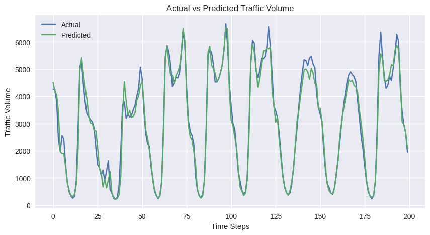

```python
plt.figure(figsize=(10,5))
plt.plot(y_test_original_scale[:200], label='Actual')
plt.plot(preds_original_scale[:200], label='Predicted')
plt.xlabel('Time Steps')
plt.ylabel('Traffic Volume')
plt.title('Actual vs Predicted Traffic Volume')
plt.legend()
plt.show()
```

**8- MODEL EVALUATION upon TEST SET(BEST MODEL- LSTM)**

```python
model.evaluate(X_test, y_test, verbose=1)
```

```
189/189 ━━━━━━━━━━━━━━━━━━━━ 1s 3ms/step - loss: 0.0199 - mae: 0.0915
```

```
[0.016672298312187195, 0.08484108746051788]
```

**9- HYPERPARAMETERS TWEAKING EXPERIMENTS**

[output not shown]

**CONCLUSION**